# Meta-Analysis Outcomes

Heike Schuler

31/08/2020

# Dataset Modifications

**Notes**:

- Only *meta*=1 are included. meta=0 do not fulfil inclusion criteria, such as which IEG, type of stressor, or type of outcome measure (i.e., gene expression studies).
- Blinding was removed after main analysis was determined. If blinding should be turned on for this summary, let me know.
- To account for multiple testing, I used the package *multcomp*, which offers contrasts with multiple testing correction. Following Viechtbauer advise, I used *Holm’s* multiple testing correction. The corrections included in the metafor package cannot be applied to the multivariate case.

## Outliers

There are 3 comparisons that would be considered outliers according to the > 3SD rule. None come from predatory journals.

I checked for outliers and influential cases in more detail with the *influence* function.

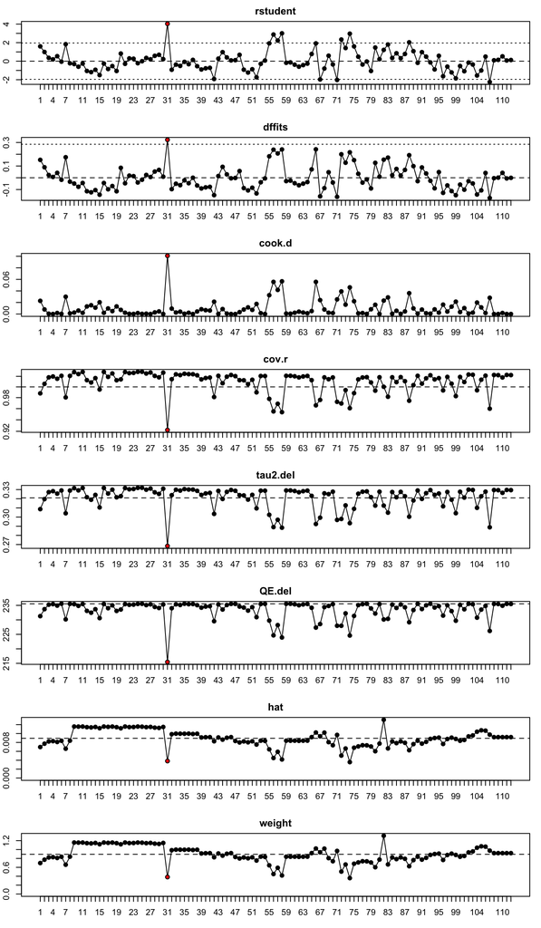

From this, only one case remains, which is considered an influential outlier across all available metrics. I removed this comparison (Clarke et al.) from the rest of the analysis.

## Final Dataset

**Excluded**:

- comparisons in brain areas other than PFC, HYP, TH, AMY, and HIP (17 publication(s); see *data_preparation.R*)
- comparisons with pooled sex (1 publication(s))
- comparisons with IEGs != cFos (8 publication(s))
- comparisons with stressor types IGT (2 publication(s)), three chamber test (1 publication(s)), and FC tasks (1 publication(s))
- comparisons with IEG = cFos, but not Protein or mRNA measurements (i.e., RNA-seq studies; 1 publication(s))

I tried many things with female rodents (i.e. everything I tried for males), but there is really nothing to be found, so I also haven’t included the results here. I believe there’s too much heterogeneity within the female sample to make conclusions based on meta-analyses - I think, for females the best way to go is by systematic review. If you want to see any analysis in particular (i.e., a specific moderator or comparison), let me know.

# Main Analysis

The main meta-analysis for male rodents includes 15 publications, 26 experiments with 111 comparisons on 342 animals. The main model tested differences between ELA and control animals, moderated by the presence of an acute stressor (Baseline vs Stressed) and brain area (HYP, HPF, TH, PFC, AMY). Frequency distributions, where n = number of comparisons, among these factors follow. Interactions between moderators are visualized below as well, but I did not analyse the full interaction effects, because there are too many levels for the sample size. Instead, below I anayzed the effects of the two moderators separately in the two research questions.

| Area | Stressor | Comps | Nests | Pubs |
| --- | --- | --- | --- | --- |
| 0 | AMY | 8 | 6 | 5 |
| 0 | HPF | 15 | 4 | 3 |
| 0 | HYP | 16 | 10 | 7 |
| 0 | PFC | 6 | 3 | 3 |
| 0 | TH | 6 | 3 | 3 |
| 1 | AMY | 11 | 7 | 6 |
| 1 | HPF | 17 | 4 | 4 |
| 1 | HYP | 15 | 9 | 8 |
| 1 | PFC | 10 | 4 | 3 |
| 1 | TH | 7 | 4 | 4 |

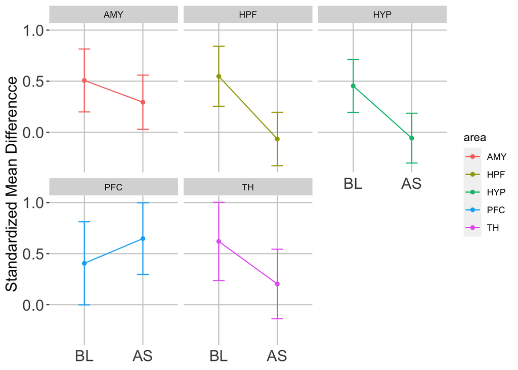

**RQ1: Effects of ELA on presence of acute stressor**

Results of contrasts suggest that at Baseline, ELA animals have sifgnicantly increased cFos expression. After acute stress, ELA and control animals do not differ from each other.

| comp | estimate | se | zval | pval |
| --- | --- | --- | --- | --- |
| baseline | 0.5067240 | 0.2270175 | 2.232092 | 0.0256089 |
| acute stress | 0.2042913 | 0.1990405 | 1.026381 | 0.3047122 |

After multiple testing correction using *Holm’s method*, results become statistically non-significant.

| comp | estimate | se | tval | pval |
| --- | --- | --- | --- | --- |
| baseline | 0.5067240 | 0.2270175 | 2.232092 | 0.0556355 |
| acute stress | 0.2042913 | 0.1990405 | 1.026381 | 0.3071641 |

**RQ2: Effects of ELA on brain area**

Results of contrasts indicate on average **increased** levels of cFos in the amygdala and prefrontal cortex in ELA animals as compared to controls.

| comp | estimate | se | zval | pval |
| --- | --- | --- | --- | --- |
| amygdala | 0.4004507 | 0.2032691 | 1.970052 | 0.0488324 |
| hippocampus | 0.2407842 | 0.1967185 | 1.224004 | 0.2209508 |
| hypothalamus | 0.1978805 | 0.1778112 | 1.112869 | 0.2657649 |
| prefrontal cortex | 0.5265960 | 0.2684882 | 1.961338 | 0.0498396 |
| thalamus | 0.4118269 | 0.2559598 | 1.608951 | 0.1076270 |

After multiple testing correction using *Holm’s methods*, results become statistically non-significant.

| comp | estimate | se | tval | pval |
| --- | --- | --- | --- | --- |
| amygdala | 0.4004507 | 0.2032691 | 1.970052 | 0.2578527 |
| hippocampus | 0.2407842 | 0.1967185 | 1.224004 | 0.4475969 |
| hypothalamus | 0.1978805 | 0.1778112 | 1.112869 | 0.4475969 |
| prefrontal cortex | 0.5265960 | 0.2684882 | 1.961338 | 0.2578527 |
| thalamus | 0.4118269 | 0.2559598 | 1.608951 | 0.3322453 |

From here on, I only report adjusted p-values!!!

# Subgroup Analysis

**Notes**:  
- After cleaning the dataset, it was no longer feasible to conduct a subgroup analysis for species (only 1 comparison != rat). Instead, I performed a sensitivity analysis for species.  
- I did check if there’s an interaction effect between 2nd hit and baseline/AS. I did not check for interaction with brain area, because there were too little samples in my opinion. The frequency distributions are shown below.

| 2nd Hit | Stressor | Comps | Nests | Pubs |
| --- | --- | --- | --- | --- |
| 0 | 0 | 17 | 3 | 3 |
| 0 | 1 | 34 | 8 | 8 |
| 1 | 0 | 34 | 9 | 8 |
| 1 | 1 | 26 | 6 | 5 |

| 2nd Hit | Stressor | Comps | Nests | Pubs |
| --- | --- | --- | --- | --- |
| 0 | AMY | 10 | 6 | 5 |
| 0 | HPF | 27 | 5 | 4 |
| 0 | HYP | 9 | 8 | 7 |
| 0 | PFC | 4 | 1 | 1 |
| 0 | TH | 1 | 1 | 1 |
| 1 | AMY | 9 | 7 | 4 |
| 1 | HPF | 5 | 3 | 2 |
| 1 | HYP | 22 | 11 | 6 |
| 1 | PFC | 12 | 6 | 3 |
| 1 | TH | 12 | 6 | 3 |

The subgroup analysis main effects are significant for 2nd hit animals, suggesting a larger effect size between control and ELA animals only if exposed to 2nd hit.

**Question: Why did you choose to make a fixed effects meta analysis for the subgroup? And why univariate? You also do a separate Wald Test to compare the two. Why are we interested in that?**

**Question: There seems to be an error in how you coded the Wald test, and since I’m not really sure why we do this, I cannot fix it. I think after the last update, you changed the construction of the contrast df in a way that this indexing doesn’t fit anymore.**

*with(comparison_hit, round(c(zval = (estimate[1] - estimate[2])/sqrt(stderror[1]^2 + stderror[2]^2)), 3))*

| comp | estimate | se | zval | pval |
| --- | --- | --- | --- | --- |
| No 2nd Hit | 0.2007621 | 0.1477552 | 1.358748 | 0.1742264 |
| 2nd Hit | 0.3774324 | 0.1246368 | 3.028258 | 0.0049194 |

I performed the same analysis but now investigating whether there is a moderating effect of acute stressor and plotted the interaction. In general, ELA animals express more cFos at baseline, independent of whether a 2nd hit was present or not. After acute stress, only ELA animals with a 2nd hit display increased cFos expression as compared to controls. However, here I show adjusted p-values, which become non-significant after adjustment.

| comp | stressor | estimate | se | zval | pval |
| --- | --- | --- | --- | --- | --- |
| No 2nd Hit | AS | 0.0083288 | 0.1872301 | 0.0444841 | 0.9645185 |
| 2nd Hit | AS | 0.4205049 | 0.1919484 | 2.1907181 | 0.1138888 |
| No 2nd Hit | BL | 0.5184636 | 0.2405720 | 2.1551285 | 0.1138888 |
| 2nd Hit | BL | 0.3460336 | 0.1638855 | 2.1114351 | 0.1138888 |

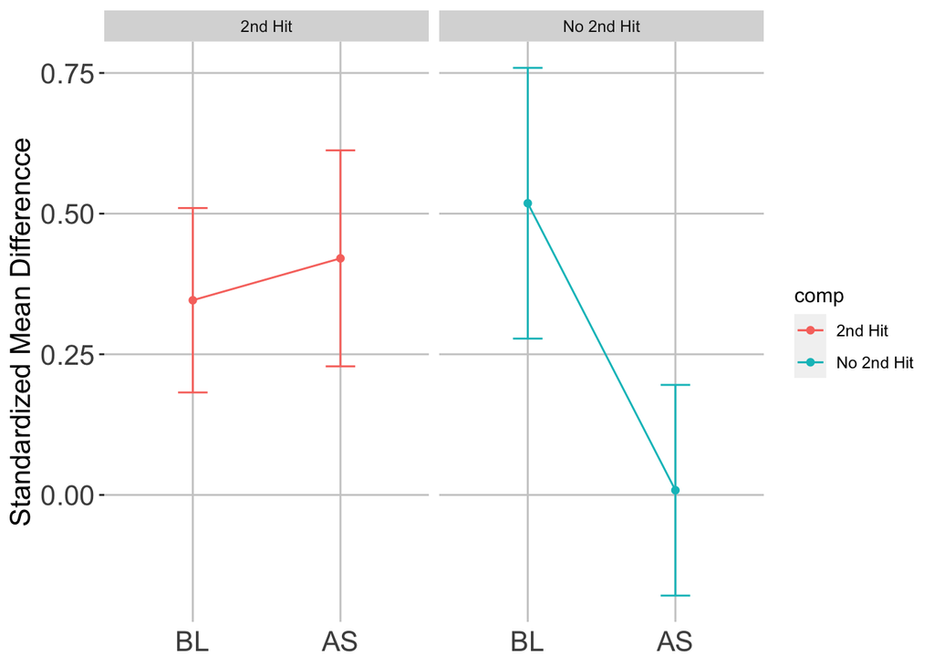

# Sensitivity Analysis

Three different sensitivity analyses were performed: Species, Model, Random/Blind Studies. Randomization might change if we disagree on this factor.

## Species

Only one publication and comparison that investigated male mice in line with our criteria. Sensitivity analysis (Wald Test) showed no significant difference between the findings, suggesting that the inclusion of this study had no effect on the main outcome.

| comp | estimate | se | zval | pval |
| --- | --- | --- | --- | --- |
| All | 0.3058871 | 0.0943365 | 3.242509 | 0.0023696 |
| Wihtout Mice | 0.2897054 | 0.0958047 | 3.023915 | 0.0024953 |

## ELA Model

The majority of comparisons were based on maternal separation model (101 comps). Sensitivity analysis (Wald Test) showed no significant difference between the findings, suggesting that the inclusion of these studies had no effect on the main outcome.

| comp | estimate | se | zval | pval |
| --- | --- | --- | --- | --- |
| All | 0.3058871 | 0.0943365 | 3.242509 | 0.0023696 |
| MS only | 0.3029398 | 0.1016160 | 2.981222 | 0.0028710 |

## Blinded & Randomized

I considered only 1 publication as completely blinded and randomized, so I did not perform this sensitivity analysis.

# Exploratory Analysis - Males

Based on frequency, we decided to explore stressor type, novelty of stressor and time between stressor and perfusion as well as which outcome measure was used (protein vs mRNA). Interaction with presence of acute stressor were assessed for non of these subgroups. Frequency distributions follow below.

## Acute Stressor - Type

Stressor types were grouped to be *physical* (i.e. application of external force/induction of physical pain) or *psychological* (i.e. exposure to novel/challenging environment) in nature. Restraint stress, in my opinion, falls between both, but I would consider it more physical than psychological. I tried sorting restraint as both, but the results of this subgroup analysis weren’t changed by that. Thoughts?

**Physical**: Colorectal distension, foot shock, shock, restraint stress.  
**Psycholoogical**: Elevated plus maze, forced swim test, novel environment, open field test.

Results below suggest that physical stressors will result in significantly enhanced cFos in ELA animals in comparison to controls, but psychological stressors do not.

| Novel | Comps | Nests | Pubs |
| --- | --- | --- | --- |
| physical | 36 | 8 | 7 |
| psychological | 24 | 6 | 6 |

| comp | estimate | se | zval | pval |
| --- | --- | --- | --- | --- |
| Physical | 0.3293053 | 0.1250621 | 2.633135 | 0.0169201 |
| Psychological | -0.2212131 | 0.2160082 | -1.024096 | 0.3057899 |

## Acute Stressor - Novelty

Differences between ELA and control animals after acute stress are non-significant for both known and novel stressors. Note, however, that only 9 comparisons report on known stressors, in comparison to 51 reporting on novel stressors.

| Novel | Comps | Nests | Pubs |
| --- | --- | --- | --- |
| 0 | 9 | 4 | 3 |
| 1 | 51 | 10 | 9 |

| comp | estimate | se | zval | pval |
| --- | --- | --- | --- | --- |
| Novel | 0.2212984 | 0.1562579 | 1.4162382 | 0.3134115 |
| Unknown | -0.1257564 | 0.3238942 | -0.3882639 | 0.6978207 |

## Acute Stressor - Time

*red* - mRNA; *blue* - protein.

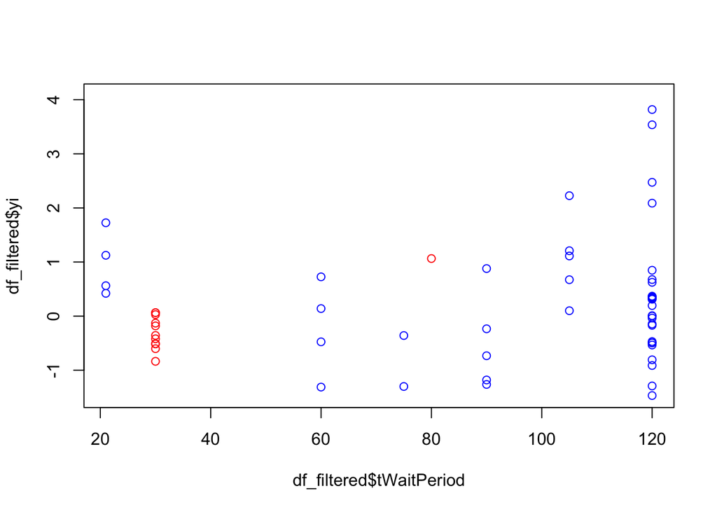

| comp | estimate | se | zval | pval |
| --- | --- | --- | --- | --- |
| Time | 0.0097059 | 0.0084377 | 1.150298 | 0.2500212 |

Binning timepoints for **protein studies** into early (=<60) and late (>60) does not alter the results.

| comp | estimate | se | zval | pval |
| --- | --- | --- | --- | --- |
| Early | 0.2310731 | 0.2211293 | 1.0449686 | 0.5920749 |
| Late | 0.1504282 | 0.1801629 | 0.8349565 | 0.5920749 |

## Outcome Measure

As expected by number of comparisons, the meta-analysis of Protein studies only shows a significant increase in cFos in ELA animals as compared to controls, whereas the meta-analsysi of mRNA studies does not. Both show average effects in the same direction and of the same size.

The mRNA meta-analysis shows no significant residual heterogeneity of studies, whereas the protein meta-analysis does.

| Stressor | Measure | Comps | Nests | Pubs |
| --- | --- | --- | --- | --- |
| 0 | M | 11 | 1 | 1 |
| 0 | P | 40 | 11 | 8 |
| 1 | M | 12 | 2 | 2 |
| 1 | P | 48 | 12 | 10 |

| comp | estimate | se | zval | pval |
| --- | --- | --- | --- | --- |
| mRNA | 0.3533173 | 0.2440164 | 1.447924 | 0.1476383 |
| Protein | 0.3208788 | 0.1106118 | 2.900945 | 0.0074408 |